# Part II - (Ford GoBike System Data)

## by Osama Badr

## Investigation Overview

> Mainly riders seem to have rides for short rides around about five minutes. Female Customer tends to have duration in the rides more than the other genders and types combinations. The peak hours in the start hours of the day at 8 A.M also seems to be after the working hours at 5 P.M

## Dataset Overview

> Biking sharing system provided by Ford for the area of San Francisco Bay with information about the person, stations, time and duration of the ride. 174952 rows of indvidual rides with 16 features. Several info about the persona demography or details about travel start and end points.

## Duration Distribution

> The distribution seems that it is right skewed, the most frequent value is about five minutes, so the bikes seems it is used mainly for short rides.

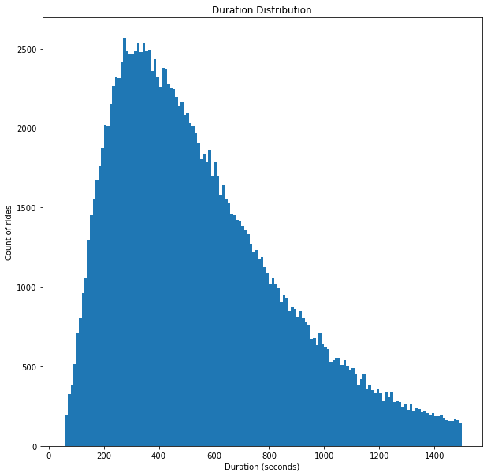

## Total rides accross the day with respect to gender

> The pattern is the same for the male and female The peak hours in the start hours of the day at 8 A.M also seems to be after the working hours at 5 P.M

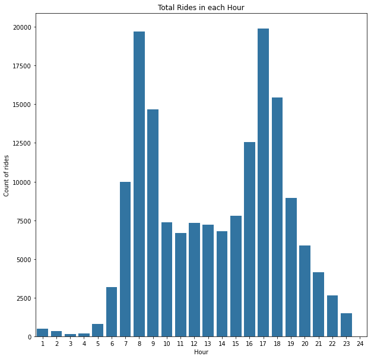

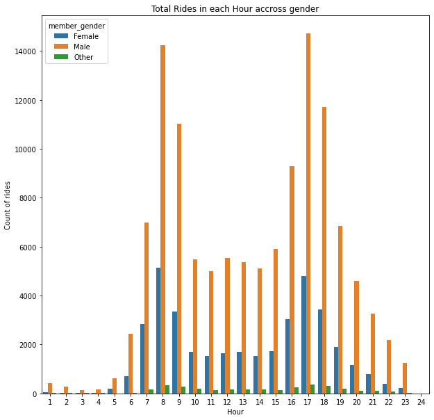

## Duration Distribution accross the gender and user type

> Female Customer tends to have duration in the rides more than the other genders and types combinations. Male Subscriber tends to have duration in the rides less than the other genders and types combinations.

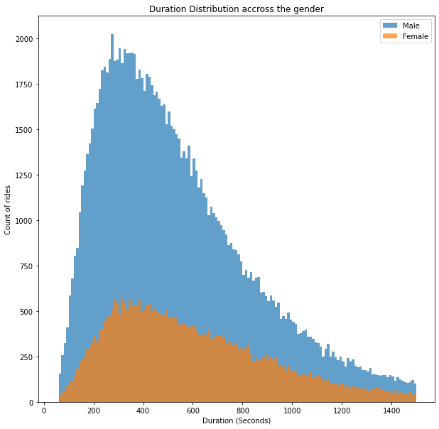

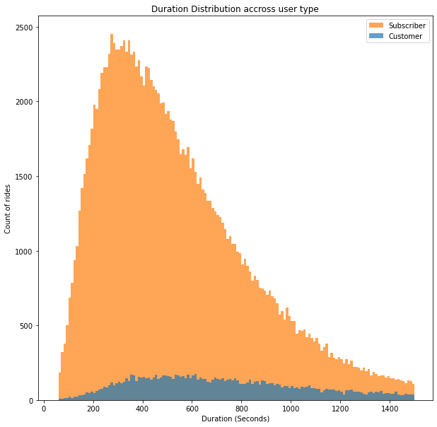

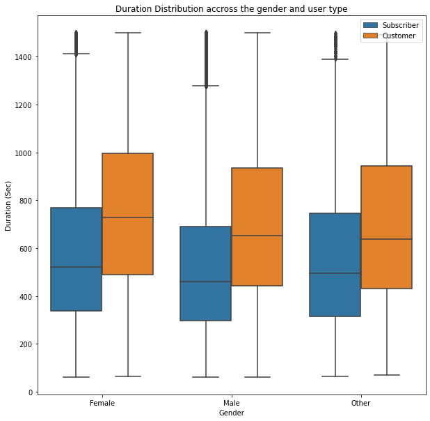